# Optimal Treatment Analysis

## Outcome Variable

**Outcome Variable:** ever_wasted

## Predictor Variables

**Intervention Variable:** nchldlt5

**Adjustment Set:**

- arm
- W_mage
- meducyrs
- feducyrs
- hhwealth_quart
- hfoodsec
- W_mhtcm
- W_nrooms
- W_parity
- impfloor
- impsan
- safeh20
- delta_W_mage
- delta_meducyrs
- delta_feducyrs
- delta_hhwealth_quart
- delta_hfoodsec
- delta_W_mhtcm
- delta_W_nrooms
- delta_W_parity
- delta_impfloor
- delta_impsan
- delta_safeh20

## Stratifying Variables

The analysis was stratified on these variable(s):

- agecat
- studyid
- country

## Data Summary

| agecat | studyid | country | nchldlt5 | ever_wasted | n_cell | n |
| --- | --- | --- | --- | --- | --- | --- |
| 0-24 months | ki1000108-IRC | INDIA | 1 | 0 | 25 | 291 |
| 0-24 months | ki1000108-IRC | INDIA | 1 | 1 | 64 | 291 |
| 0-24 months | ki1000108-IRC | INDIA | 2+ | 0 | 69 | 291 |
| 0-24 months | ki1000108-IRC | INDIA | 2+ | 1 | 133 | 291 |
| 0-24 months | ki1017093b-PROVIDE | BANGLADESH | 1 | 0 | 327 | 524 |
| 0-24 months | ki1017093b-PROVIDE | BANGLADESH | 1 | 1 | 185 | 524 |
| 0-24 months | ki1017093b-PROVIDE | BANGLADESH | 2+ | 0 | 6 | 524 |
| 0-24 months | ki1017093b-PROVIDE | BANGLADESH | 2+ | 1 | 6 | 524 |
| 0-24 months | ki1017093c-NIH-Crypto | BANGLADESH | 1 | 0 | 368 | 547 |
| 0-24 months | ki1017093c-NIH-Crypto | BANGLADESH | 1 | 1 | 173 | 547 |
| 0-24 months | ki1017093c-NIH-Crypto | BANGLADESH | 2+ | 0 | 4 | 547 |
| 0-24 months | ki1017093c-NIH-Crypto | BANGLADESH | 2+ | 1 | 2 | 547 |
| 0-24 months | ki1066203-TanzaniaChild2 | TANZANIA, UNITED REPUBLIC OF | 1 | 0 | 1242 | 1716 |
| 0-24 months | ki1066203-TanzaniaChild2 | TANZANIA, UNITED REPUBLIC OF | 1 | 1 | 395 | 1716 |
| 0-24 months | ki1066203-TanzaniaChild2 | TANZANIA, UNITED REPUBLIC OF | 2+ | 0 | 61 | 1716 |
| 0-24 months | ki1066203-TanzaniaChild2 | TANZANIA, UNITED REPUBLIC OF | 2+ | 1 | 18 | 1716 |
| 0-24 months | ki1112895-iLiNS-Zinc | BURKINA FASO | 1 | 0 | 207 | 481 |
| 0-24 months | ki1112895-iLiNS-Zinc | BURKINA FASO | 1 | 1 | 55 | 481 |
| 0-24 months | ki1112895-iLiNS-Zinc | BURKINA FASO | 2+ | 0 | 168 | 481 |
| 0-24 months | ki1112895-iLiNS-Zinc | BURKINA FASO | 2+ | 1 | 51 | 481 |
| 0-24 months | ki1148112-LCNI-5 | MALAWI | 1 | 0 | 366 | 454 |
| 0-24 months | ki1148112-LCNI-5 | MALAWI | 1 | 1 | 25 | 454 |
| 0-24 months | ki1148112-LCNI-5 | MALAWI | 2+ | 0 | 58 | 454 |
| 0-24 months | ki1148112-LCNI-5 | MALAWI | 2+ | 1 | 5 | 454 |
| 0-24 months | kiGH5241-JiVitA-3 | BANGLADESH | 1 | 0 | 6226 | 8807 |
| 0-24 months | kiGH5241-JiVitA-3 | BANGLADESH | 1 | 1 | 2269 | 8807 |
| 0-24 months | kiGH5241-JiVitA-3 | BANGLADESH | 2+ | 0 | 223 | 8807 |
| 0-24 months | kiGH5241-JiVitA-3 | BANGLADESH | 2+ | 1 | 89 | 8807 |
| 0-6 months | ki1000108-IRC | INDIA | 1 | 0 | 37 | 291 |
| 0-6 months | ki1000108-IRC | INDIA | 1 | 1 | 52 | 291 |
| 0-6 months | ki1000108-IRC | INDIA | 2+ | 0 | 95 | 291 |
| 0-6 months | ki1000108-IRC | INDIA | 2+ | 1 | 107 | 291 |
| 0-6 months | ki1017093b-PROVIDE | BANGLADESH | 1 | 0 | 375 | 524 |
| 0-6 months | ki1017093b-PROVIDE | BANGLADESH | 1 | 1 | 137 | 524 |
| 0-6 months | ki1017093b-PROVIDE | BANGLADESH | 2+ | 0 | 8 | 524 |
| 0-6 months | ki1017093b-PROVIDE | BANGLADESH | 2+ | 1 | 4 | 524 |
| 0-6 months | ki1017093c-NIH-Crypto | BANGLADESH | 1 | 0 | 404 | 547 |
| 0-6 months | ki1017093c-NIH-Crypto | BANGLADESH | 1 | 1 | 137 | 547 |
| 0-6 months | ki1017093c-NIH-Crypto | BANGLADESH | 2+ | 0 | 4 | 547 |
| 0-6 months | ki1017093c-NIH-Crypto | BANGLADESH | 2+ | 1 | 2 | 547 |
| 0-6 months | ki1066203-TanzaniaChild2 | TANZANIA, UNITED REPUBLIC OF | 1 | 0 | 1407 | 1716 |
| 0-6 months | ki1066203-TanzaniaChild2 | TANZANIA, UNITED REPUBLIC OF | 1 | 1 | 230 | 1716 |
| 0-6 months | ki1066203-TanzaniaChild2 | TANZANIA, UNITED REPUBLIC OF | 2+ | 0 | 64 | 1716 |
| 0-6 months | ki1066203-TanzaniaChild2 | TANZANIA, UNITED REPUBLIC OF | 2+ | 1 | 15 | 1716 |
| 0-6 months | ki1148112-LCNI-5 | MALAWI | 1 | 0 | 121 | 145 |
| 0-6 months | ki1148112-LCNI-5 | MALAWI | 1 | 1 | 1 | 145 |
| 0-6 months | ki1148112-LCNI-5 | MALAWI | 2+ | 0 | 23 | 145 |
| 0-6 months | ki1148112-LCNI-5 | MALAWI | 2+ | 1 | 0 | 145 |
| 0-6 months | kiGH5241-JiVitA-3 | BANGLADESH | 1 | 0 | 6866 | 8765 |
| 0-6 months | kiGH5241-JiVitA-3 | BANGLADESH | 1 | 1 | 1588 | 8765 |
| 0-6 months | kiGH5241-JiVitA-3 | BANGLADESH | 2+ | 0 | 254 | 8765 |
| 0-6 months | kiGH5241-JiVitA-3 | BANGLADESH | 2+ | 1 | 57 | 8765 |
| 6-24 months | ki1000108-IRC | INDIA | 1 | 0 | 56 | 291 |
| 6-24 months | ki1000108-IRC | INDIA | 1 | 1 | 33 | 291 |
| 6-24 months | ki1000108-IRC | INDIA | 2+ | 0 | 134 | 291 |
| 6-24 months | ki1000108-IRC | INDIA | 2+ | 1 | 68 | 291 |
| 6-24 months | ki1017093b-PROVIDE | BANGLADESH | 1 | 0 | 380 | 458 |
| 6-24 months | ki1017093b-PROVIDE | BANGLADESH | 1 | 1 | 68 | 458 |
| 6-24 months | ki1017093b-PROVIDE | BANGLADESH | 2+ | 0 | 8 | 458 |
| 6-24 months | ki1017093b-PROVIDE | BANGLADESH | 2+ | 1 | 2 | 458 |
| 6-24 months | ki1017093c-NIH-Crypto | BANGLADESH | 1 | 0 | 460 | 525 |
| 6-24 months | ki1017093c-NIH-Crypto | BANGLADESH | 1 | 1 | 60 | 525 |
| 6-24 months | ki1017093c-NIH-Crypto | BANGLADESH | 2+ | 0 | 4 | 525 |
| 6-24 months | ki1017093c-NIH-Crypto | BANGLADESH | 2+ | 1 | 1 | 525 |
| 6-24 months | ki1066203-TanzaniaChild2 | TANZANIA, UNITED REPUBLIC OF | 1 | 0 | 1154 | 1447 |
| 6-24 months | ki1066203-TanzaniaChild2 | TANZANIA, UNITED REPUBLIC OF | 1 | 1 | 229 | 1447 |
| 6-24 months | ki1066203-TanzaniaChild2 | TANZANIA, UNITED REPUBLIC OF | 2+ | 0 | 58 | 1447 |
| 6-24 months | ki1066203-TanzaniaChild2 | TANZANIA, UNITED REPUBLIC OF | 2+ | 1 | 6 | 1447 |
| 6-24 months | ki1112895-iLiNS-Zinc | BURKINA FASO | 1 | 0 | 207 | 481 |
| 6-24 months | ki1112895-iLiNS-Zinc | BURKINA FASO | 1 | 1 | 55 | 481 |
| 6-24 months | ki1112895-iLiNS-Zinc | BURKINA FASO | 2+ | 0 | 168 | 481 |
| 6-24 months | ki1112895-iLiNS-Zinc | BURKINA FASO | 2+ | 1 | 51 | 481 |
| 6-24 months | ki1148112-LCNI-5 | MALAWI | 1 | 0 | 360 | 446 |
| 6-24 months | ki1148112-LCNI-5 | MALAWI | 1 | 1 | 24 | 446 |
| 6-24 months | ki1148112-LCNI-5 | MALAWI | 2+ | 0 | 57 | 446 |
| 6-24 months | ki1148112-LCNI-5 | MALAWI | 2+ | 1 | 5 | 446 |
| 6-24 months | kiGH5241-JiVitA-3 | BANGLADESH | 1 | 0 | 4651 | 5714 |
| 6-24 months | kiGH5241-JiVitA-3 | BANGLADESH | 1 | 1 | 872 | 5714 |
| 6-24 months | kiGH5241-JiVitA-3 | BANGLADESH | 2+ | 0 | 151 | 5714 |
| 6-24 months | kiGH5241-JiVitA-3 | BANGLADESH | 2+ | 1 | 40 | 5714 |

The following strata were considered:

- agecat: 0-24 months, studyid: ki1000108-IRC, country: INDIA
- agecat: 0-24 months, studyid: ki1017093b-PROVIDE, country: BANGLADESH
- agecat: 0-24 months, studyid: ki1017093c-NIH-Crypto, country: BANGLADESH
- agecat: 0-24 months, studyid: ki1066203-TanzaniaChild2, country: TANZANIA, UNITED REPUBLIC OF
- agecat: 0-24 months, studyid: ki1112895-iLiNS-Zinc, country: BURKINA FASO
- agecat: 0-24 months, studyid: ki1148112-LCNI-5, country: MALAWI
- agecat: 0-24 months, studyid: kiGH5241-JiVitA-3, country: BANGLADESH
- agecat: 0-6 months, studyid: ki1000108-IRC, country: INDIA
- agecat: 0-6 months, studyid: ki1017093b-PROVIDE, country: BANGLADESH
- agecat: 0-6 months, studyid: ki1017093c-NIH-Crypto, country: BANGLADESH
- agecat: 0-6 months, studyid: ki1066203-TanzaniaChild2, country: TANZANIA, UNITED REPUBLIC OF
- agecat: 0-6 months, studyid: ki1148112-LCNI-5, country: MALAWI
- agecat: 0-6 months, studyid: kiGH5241-JiVitA-3, country: BANGLADESH
- agecat: 6-24 months, studyid: ki1000108-IRC, country: INDIA
- agecat: 6-24 months, studyid: ki1017093b-PROVIDE, country: BANGLADESH
- agecat: 6-24 months, studyid: ki1017093c-NIH-Crypto, country: BANGLADESH
- agecat: 6-24 months, studyid: ki1066203-TanzaniaChild2, country: TANZANIA, UNITED REPUBLIC OF
- agecat: 6-24 months, studyid: ki1112895-iLiNS-Zinc, country: BURKINA FASO
- agecat: 6-24 months, studyid: ki1148112-LCNI-5, country: MALAWI
- agecat: 6-24 months, studyid: kiGH5241-JiVitA-3, country: BANGLADESH

### Dropped Strata

Some strata were dropped due to rare outcomes:

- agecat: 0-24 months, studyid: ki1017093c-NIH-Crypto, country: BANGLADESH
- agecat: 0-6 months, studyid: ki1017093b-PROVIDE, country: BANGLADESH
- agecat: 0-6 months, studyid: ki1017093c-NIH-Crypto, country: BANGLADESH
- agecat: 0-6 months, studyid: ki1148112-LCNI-5, country: MALAWI
- agecat: 6-24 months, studyid: ki1017093b-PROVIDE, country: BANGLADESH
- agecat: 6-24 months, studyid: ki1017093c-NIH-Crypto, country: BANGLADESH

## Methods Detail

We’re interested in the causal parameters $E[Y_a]$ for all values of $a \in \mathcal{A}$. These parameters represent the mean outcome if, possibly contrary to fact, we intervened to set all units to have $A=a$. Under the randomization and positivity assumptions, these are identified by the statistical parameters $\psi_a=E_W[E_{Y|A,W}(Y|A=a,W)]$. In addition, we’re interested in the mean of $Y$, $E[Y]$ under no intervention (the observed mean). We will estimate these parameters by using SuperLearner to fit the relevant likelihood factors – $E_{Y|A,W}(Y|A=a,W)$ and $p(A=a|W)$, and then updating our likelihood fit using a joint TMLE.

For unadjusted analyses ($W=\{\}$), initial likelihoods were estimated using Lrnr_glm to estimate the simple $E(Y|A)$ and Lrnr_mean to estimate $p(A)$. For adjusted analyses, a small library containing Lrnr_glmnet, Lrnr_xgboost, and Lrnr_mean was used.

Having estimated these parameters, we will then use the delta method to estimate relative risks and attributable risks relative to a prespecified baseline level of $A$.

# Results Detail

## Results Plots

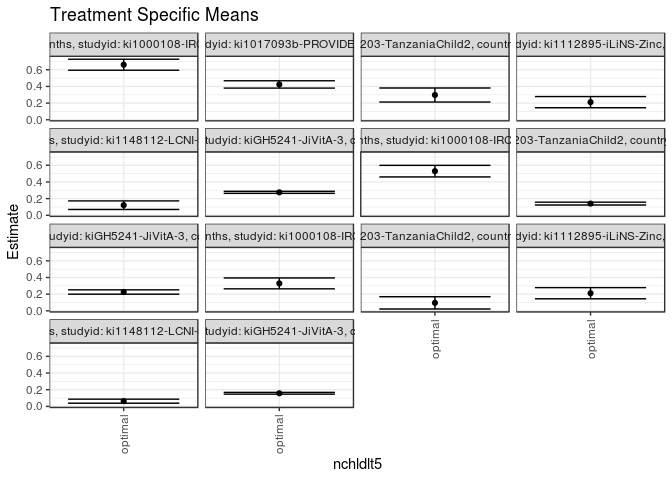

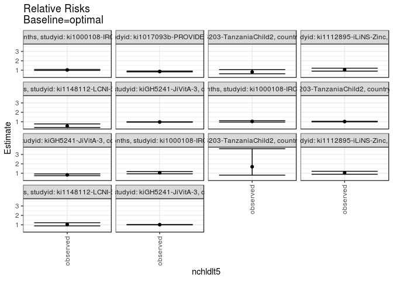

## Results Table

### Parameter: TSM

| agecat | studyid | country | intervention_level | baseline_level | estimate | ci_lower | ci_upper |
| --- | --- | --- | --- | --- | --- | --- | --- |
| 0-24 months | ki1000108-IRC | INDIA | optimal | NA | 0.6600106 | 0.5940576 | 0.7259636 |
| 0-24 months | ki1017093b-PROVIDE | BANGLADESH | optimal | NA | 0.4237543 | 0.3799575 | 0.4675512 |
| 0-24 months | ki1066203-TanzaniaChild2 | TANZANIA, UNITED REPUBLIC OF | optimal | NA | 0.2969620 | 0.2128186 | 0.3811053 |
| 0-24 months | ki1112895-iLiNS-Zinc | BURKINA FASO | optimal | NA | 0.2113464 | 0.1444272 | 0.2782656 |
| 0-24 months | ki1148112-LCNI-5 | MALAWI | optimal | NA | 0.1214842 | 0.0701333 | 0.1728352 |
| 0-24 months | kiGH5241-JiVitA-3 | BANGLADESH | optimal | NA | 0.2756318 | 0.2634574 | 0.2878061 |
| 0-6 months | ki1000108-IRC | INDIA | optimal | NA | 0.5297030 | 0.4602396 | 0.5991663 |
| 0-6 months | ki1066203-TanzaniaChild2 | TANZANIA, UNITED REPUBLIC OF | optimal | NA | 0.1405300 | 0.1236873 | 0.1573727 |
| 0-6 months | kiGH5241-JiVitA-3 | BANGLADESH | optimal | NA | 0.2260008 | 0.1996815 | 0.2523201 |
| 6-24 months | ki1000108-IRC | INDIA | optimal | NA | 0.3293214 | 0.2638910 | 0.3947519 |
| 6-24 months | ki1066203-TanzaniaChild2 | TANZANIA, UNITED REPUBLIC OF | optimal | NA | 0.0957784 | 0.0222991 | 0.1692576 |
| 6-24 months | ki1112895-iLiNS-Zinc | BURKINA FASO | optimal | NA | 0.2113464 | 0.1444272 | 0.2782656 |
| 6-24 months | ki1148112-LCNI-5 | MALAWI | optimal | NA | 0.0625943 | 0.0383341 | 0.0868546 |
| 6-24 months | kiGH5241-JiVitA-3 | BANGLADESH | optimal | NA | 0.1572451 | 0.1466695 | 0.1678207 |

### Parameter: E(Y)

| agecat | studyid | country | intervention_level | baseline_level | estimate | ci_lower | ci_upper |
| --- | --- | --- | --- | --- | --- | --- | --- |
| 0-24 months | ki1000108-IRC | INDIA | observed | NA | 0.6769759 | 0.6231548 | 0.7307971 |
| 0-24 months | ki1017093b-PROVIDE | BANGLADESH | observed | NA | 0.3645038 | 0.3232556 | 0.4057520 |
| 0-24 months | ki1066203-TanzaniaChild2 | TANZANIA, UNITED REPUBLIC OF | observed | NA | 0.2406760 | 0.2204437 | 0.2609083 |
| 0-24 months | ki1112895-iLiNS-Zinc | BURKINA FASO | observed | NA | 0.2203742 | 0.1753372 | 0.2654112 |
| 0-24 months | ki1148112-LCNI-5 | MALAWI | observed | NA | 0.0660793 | 0.0432029 | 0.0889556 |
| 0-24 months | kiGH5241-JiVitA-3 | BANGLADESH | observed | NA | 0.2677416 | 0.2574329 | 0.2780502 |
| 0-6 months | ki1000108-IRC | INDIA | observed | NA | 0.5463918 | 0.4890935 | 0.6036900 |
| 0-6 months | ki1066203-TanzaniaChild2 | TANZANIA, UNITED REPUBLIC OF | observed | NA | 0.1427739 | 0.1262166 | 0.1593311 |
| 0-6 months | kiGH5241-JiVitA-3 | BANGLADESH | observed | NA | 0.1876783 | 0.1782550 | 0.1971016 |
| 6-24 months | ki1000108-IRC | INDIA | observed | NA | 0.3470790 | 0.2922900 | 0.4018681 |
| 6-24 months | ki1066203-TanzaniaChild2 | TANZANIA, UNITED REPUBLIC OF | observed | NA | 0.1624050 | 0.1433950 | 0.1814149 |
| 6-24 months | ki1112895-iLiNS-Zinc | BURKINA FASO | observed | NA | 0.2203742 | 0.1753372 | 0.2654112 |
| 6-24 months | ki1148112-LCNI-5 | MALAWI | observed | NA | 0.0650224 | 0.0421137 | 0.0879311 |
| 6-24 months | kiGH5241-JiVitA-3 | BANGLADESH | observed | NA | 0.1596080 | 0.1492650 | 0.1699509 |

### Parameter: RR

| agecat | studyid | country | intervention_level | baseline_level | estimate | ci_lower | ci_upper |
| --- | --- | --- | --- | --- | --- | --- | --- |
| 0-24 months | ki1000108-IRC | INDIA | observed | optimal | 1.0257047 | 0.9712109 | 1.0832560 |
| 0-24 months | ki1017093b-PROVIDE | BANGLADESH | observed | optimal | 0.8601772 | 0.8152247 | 0.9076085 |
| 0-24 months | ki1066203-TanzaniaChild2 | TANZANIA, UNITED REPUBLIC OF | observed | optimal | 0.8104606 | 0.6171784 | 1.0642732 |
| 0-24 months | ki1112895-iLiNS-Zinc | BURKINA FASO | observed | optimal | 1.0427158 | 0.8970655 | 1.2120143 |
| 0-24 months | ki1148112-LCNI-5 | MALAWI | observed | optimal | 0.5439331 | 0.3854776 | 0.7675238 |
| 0-24 months | kiGH5241-JiVitA-3 | BANGLADESH | observed | optimal | 0.9713741 | 0.9487026 | 0.9945874 |
| 0-6 months | ki1000108-IRC | INDIA | observed | optimal | 1.0315060 | 0.9587580 | 1.1097738 |
| 0-6 months | ki1066203-TanzaniaChild2 | TANZANIA, UNITED REPUBLIC OF | observed | optimal | 1.0159673 | 0.9869266 | 1.0458626 |
| 0-6 months | kiGH5241-JiVitA-3 | BANGLADESH | observed | optimal | 0.8304318 | 0.7415642 | 0.9299491 |
| 6-24 months | ki1000108-IRC | INDIA | observed | optimal | 1.0539218 | 0.9408100 | 1.1806328 |
| 6-24 months | ki1066203-TanzaniaChild2 | TANZANIA, UNITED REPUBLIC OF | observed | optimal | 1.6956334 | 0.7956817 | 3.6134706 |
| 6-24 months | ki1112895-iLiNS-Zinc | BURKINA FASO | observed | optimal | 1.0427158 | 0.8970655 | 1.2120143 |
| 6-24 months | ki1148112-LCNI-5 | MALAWI | observed | optimal | 1.0387907 | 0.8851800 | 1.2190584 |
| 6-24 months | kiGH5241-JiVitA-3 | BANGLADESH | observed | optimal | 1.0150267 | 0.9984626 | 1.0318656 |

### Parameter: PAR

| agecat | studyid | country | intervention_level | baseline_level | estimate | ci_lower | ci_upper |
| --- | --- | --- | --- | --- | --- | --- | --- |
| 0-24 months | ki1000108-IRC | INDIA | optimal | NA | 0.0169654 | -0.0189844 | 0.0529151 |
| 0-24 months | ki1017093b-PROVIDE | BANGLADESH | optimal | NA | -0.0592505 | -0.0801463 | -0.0383548 |
| 0-24 months | ki1066203-TanzaniaChild2 | TANZANIA, UNITED REPUBLIC OF | optimal | NA | -0.0562860 | -0.1372260 | 0.0246540 |
| 0-24 months | ki1112895-iLiNS-Zinc | BURKINA FASO | optimal | NA | 0.0090278 | -0.0217312 | 0.0397868 |
| 0-24 months | ki1148112-LCNI-5 | MALAWI | optimal | NA | -0.0554049 | -0.0968256 | -0.0139843 |
| 0-24 months | kiGH5241-JiVitA-3 | BANGLADESH | optimal | NA | -0.0078902 | -0.0143918 | -0.0013886 |
| 0-6 months | ki1000108-IRC | INDIA | optimal | NA | 0.0166888 | -0.0219942 | 0.0553718 |
| 0-6 months | ki1066203-TanzaniaChild2 | TANZANIA, UNITED REPUBLIC OF | optimal | NA | 0.0022439 | -0.0018370 | 0.0063248 |
| 0-6 months | kiGH5241-JiVitA-3 | BANGLADESH | optimal | NA | -0.0383226 | -0.0636740 | -0.0129711 |
| 6-24 months | ki1000108-IRC | INDIA | optimal | NA | 0.0177576 | -0.0196058 | 0.0551210 |
| 6-24 months | ki1066203-TanzaniaChild2 | TANZANIA, UNITED REPUBLIC OF | optimal | NA | 0.0666266 | -0.0061537 | 0.1394069 |
| 6-24 months | ki1112895-iLiNS-Zinc | BURKINA FASO | optimal | NA | 0.0090278 | -0.0217312 | 0.0397868 |
| 6-24 months | ki1148112-LCNI-5 | MALAWI | optimal | NA | 0.0024281 | -0.0076212 | 0.0124773 |
| 6-24 months | kiGH5241-JiVitA-3 | BANGLADESH | optimal | NA | 0.0023629 | -0.0002251 | 0.0049508 |

### Parameter: PAF

| agecat | studyid | country | intervention_level | baseline_level | estimate | ci_lower | ci_upper |
| --- | --- | --- | --- | --- | --- | --- | --- |
| 0-24 months | ki1000108-IRC | INDIA | optimal | NA | 0.0250605 | -0.0296424 | 0.0768572 |
| 0-24 months | ki1017093b-PROVIDE | BANGLADESH | optimal | NA | -0.1625512 | -0.2266557 | -0.1017967 |
| 0-24 months | ki1066203-TanzaniaChild2 | TANZANIA, UNITED REPUBLIC OF | optimal | NA | -0.2338662 | -0.6202771 | 0.0603916 |
| 0-24 months | ki1112895-iLiNS-Zinc | BURKINA FASO | optimal | NA | 0.0409659 | -0.1147458 | 0.1749272 |
| 0-24 months | ki1148112-LCNI-5 | MALAWI | optimal | NA | -0.8384613 | -1.5941843 | -0.3028912 |
| 0-24 months | kiGH5241-JiVitA-3 | BANGLADESH | optimal | NA | -0.0294695 | -0.0540712 | -0.0054421 |
| 0-6 months | ki1000108-IRC | INDIA | optimal | NA | 0.0305437 | -0.0430160 | 0.0989155 |
| 0-6 months | ki1066203-TanzaniaChild2 | TANZANIA, UNITED REPUBLIC OF | optimal | NA | 0.0157164 | -0.0132466 | 0.0438515 |
| 0-6 months | kiGH5241-JiVitA-3 | BANGLADESH | optimal | NA | -0.2041928 | -0.3485009 | -0.0753276 |
| 6-24 months | ki1000108-IRC | INDIA | optimal | NA | 0.0511630 | -0.0629139 | 0.1529966 |
| 6-24 months | ki1066203-TanzaniaChild2 | TANZANIA, UNITED REPUBLIC OF | optimal | NA | 0.4102499 | -0.2567839 | 0.7232577 |
| 6-24 months | ki1112895-iLiNS-Zinc | BURKINA FASO | optimal | NA | 0.0409659 | -0.1147458 | 0.1749272 |
| 6-24 months | ki1148112-LCNI-5 | MALAWI | optimal | NA | 0.0373421 | -0.1297138 | 0.1796948 |
| 6-24 months | kiGH5241-JiVitA-3 | BANGLADESH | optimal | NA | 0.0148043 | -0.0015398 | 0.0308816 |